# Pleiotropic Bias Simulations for Egger Regression

Rachael Aikens

June 20, 2016

## Summary

This RMarkdown gives overview and code for simulating gene-outcome and gene-exposure associations for Egger Regression analysis based on preset parameters for bias and exposure-outcome effect. The details of the simulation model are explained in the Supplimentary Information from this report.

## The ER.sim Function

**Summary:** Generates simulated gene-exposure data for a set of SNPs with a given level of bias and noise. Runs Egger regression on these simulations and reports the results.

**Inputs:**

- “bias” a vector containing the upper and lower bounds for a uniformly distributed pleiotropic bias to be added to the data
- “BetaXG” a vector of Gene-exposure associations
- “sd” a vector of desired standard deviations for noise to be added to the gene-outcome associations
- “alpha” the true effect of exposure on outcome (preset 0.02)
- “n” the number of simulations to run (preset 10000)

**Outputs:** a dataframe with n rows and 4 columns. Each row gives the effect and bias estimate with two booleans, “Beta.Ha,” and “Bias.Ha”. The boolean is TRUE if the simulation detected nonzero beta or bias, respectively.

```r
ER.sim <- function(bias, BetaXG, sd, alpha, n = 10000) {

  #initialize data frame to hold results
  result <- data.frame(matrix(ncol=4,nrow=n))
  colnames(result) <- c("Beta", "Beta.Ha", "Bias", "Bias.Ha")

  #pre-processing ensuring all gene-exposure estimates are postitive
  BXG <- abs(BetaXG)

  for (i in 1:n){
    #Generate SNP associations
    n.SNPs <- length(sd)
    BYG <- rnorm(n.SNPs, mean=alpha*BXG, sd=sd) + runif(n.SNPs, min = bias[1], max = bias[2]) #add uniformly distributed bias based on set limits

    #Egger regression
    ERfit <- summary(lm(BYG~BXG,weights=1/sd^2))
    ER.bias <- ERfit$coef[1,1]
    ER.beta <- ERfit$coef[2,1]

    #asymptotic correction for SE
    SE.bias <- ERfit$coef[1,2]/ERfit$sigma
    SE.beta <- ERfit$coef[2,2]/ERfit$sigma

    #t-test for singificance
    DF <- length(BYG)-2
    ER.bias.p <- 2*(1-pt(abs(ER.bias/SE.bias),DF))
    ER.beta.p <- 2*(1-pt(abs(ER.beta/SE.beta),DF))

    #store results
    result$Beta[i] <- ER.beta
    result$Beta.Ha[i] <- ER.beta.p < 0.05
    result$Bias[i] <- ER.bias
    result$Bias.Ha[i] <- ER.bias.p < 0.05
  }

  return(result)
}
```

## Sample analysis with ER.sim

Below, we will demonstrate a sample analysis using different levels and directions of bias. For our analysis, we used the SBP associations from our conservative instrument of 13 SNPsas our gene-exposure associations, and the standard error in our T2D associations estimates as our standard deviation for adding noise to the data.

```r
#vector of gene-exposure associations (SBP)
BetaXG <- c(0.357, 0.329, 0.732, 0.903, 0.620, 0.485, 0.355, 0.318, 0.951, 0.553, 0.520, 0.327, 0.471)

#Vector of standard errors in gene-outcome associations
se.BetaYG <- c(0.0128, 0.0103, 0.0115, 0.0142, 0.0125, 0.0126, 0.0164, 0.0169, 0.0157, 0.0117, 0.0155, 0.0113, 0.0106)
```

We analyzed Egger Regression power and accuracy under four different models:

- No bias
- Positive bias
- Negative bias
- Nondirectional bias

For more information on these models, see the supplimentary information from this report.

```r
trials <- c("No bias", "Positive bias", "Negative bias", "Nondirectional bias")

#Run simulations with different bias ranges
no.bias <- ER.sim(bias = c(0,0), BetaXG = BetaXG, sd = se.BetaYG, alpha = 0.02)
pos.bias <- ER.sim(bias = c(0, 0.04), BetaXG = BetaXG, sd = se.BetaYG, alpha = 0.02)
neg.bias <- ER.sim(bias = c(-0.04, 0), BetaXG = BetaXG, sd = se.BetaYG, alpha = 0.02)
nondir.bias <- ER.sim(bias = c(-0.04, 0.04), BetaXG = BetaXG, sd = se.BetaYG, alpha = 0.02)

#Estimating power
result.power <- data.frame(matrix(ncol=4,nrow=2))
rownames(result.power) <- c("Beta estimate", "Bias Estimate")

result.power$X1 <- c(mean(no.bias$Beta.Ha), mean(no.bias$Bias.Ha))
result.power$X2 <- c(mean(pos.bias$Beta.Ha), mean(pos.bias$Bias.Ha))
result.power$X3 <- c(mean(neg.bias$Beta.Ha), mean(neg.bias$Bias.Ha))
result.power$X4 <- c(mean(nondir.bias$Beta.Ha), mean(nondir.bias$Bias.Ha))
colnames(result.power) <- trials

#show this result
result.power
```

```
##               No bias Positive bias Negative bias Nondirectional bias
## Beta estimate  0.1336        0.2173        0.2066              0.3549
## Bias Estimate  0.0276        0.4361        0.4280              0.2983
```

```r
#Results of Beta estimates
result.beta <- data.frame(matrix(ncol=4,nrow=10000))
result.beta$X1 <- no.bias$Beta
result.beta$X2 <- pos.bias$Beta
result.beta$X3 <- neg.bias$Beta
result.beta$X4 <- nondir.bias$Beta
colnames(result.beta) <- trials

#Results of Bias estimates
result.bias <- data.frame(matrix(ncol=4,nrow=10000))
result.bias$X1 <- no.bias$Bias
result.bias$X2 <- pos.bias$Bias
result.bias$X3 <- neg.bias$Bias
result.bias$X4 <- nondir.bias$Bias
colnames(result.bias) <- trials
```

## Visualizing Results

The following R code generates boxplots in ggplot2 to visualize the simulation results

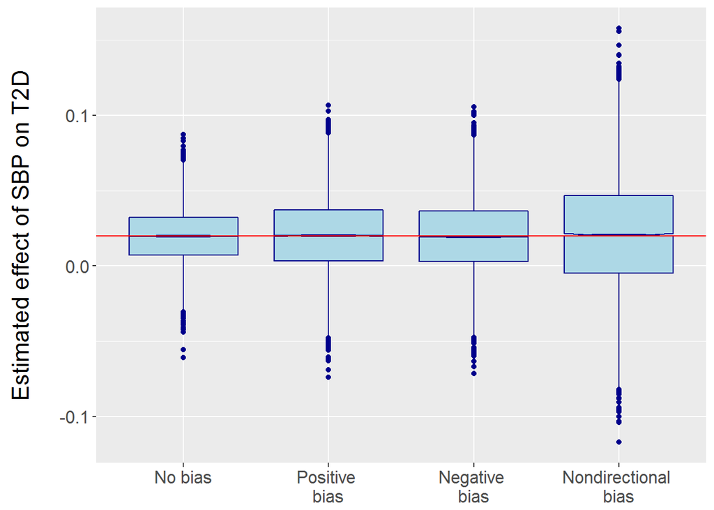

```r
library(ggplot2)
library(plyr)
require(reshape2)
myboxplot <- function(ylabel, alpha, result){
  data <- melt(result)

  #Make the plot
  box.p <- ggplot(data, aes(variable,value)) +
    geom_boxplot(notch=TRUE, fill = "light blue", colour = "dark blue", lwd = 0.5) +
    labs(y = ylabel) + #y axis label
    geom_hline(yintercept = alpha , color = "red") + #horizontal line at true effect size
    theme(axis.text.x = element_text(size = rel(1.4)), axis.title.x = element_blank(), #adjust text sizes
          axis.title.y = element_text(size = rel(1.5)), axis.text.y = element_text(size = rel(1.4)))
  return(box.p)
}

colnames(result.beta) <- c("No bias", "Positive \nbias", "Negative \nbias", "Nondirectional \nbias")
myboxplot(ylabel = "Estimated effect of SBP on T2D\n", alpha = 0.02, result = result.beta)
```